# IS682_Midterm_Dave

Aditya Dave

3/16/2021

## PART 1

```r
require(tidyverse)
require(tidymodels)
claims=read_csv(url('https://ygenc.github.io/lectures/data/auto_claims.csv'))
```

##Dataset

```r
claims
```

```
## # A tibble: 6,249 x 17
##    customer_id customer_state highest_educati~ employment_stat~ gender income
##    <chr>       <chr>          <chr>            <chr>            <chr>   <dbl>
##  1 AA11235     Nevada         Bachelor         Medical Leave    Female  11167
##  2 AA16582     Washington     Bachelor         Medical Leave    Male    14072
##  3 AA34092     California     Associate        Employed         Male    33635
##  4 AA56476     Arizona        High School      Employed         Female  74454
##  5 AA69265     Nevada         Bachelor         Employed         Female  60817
##  6 AA71604     Arizona        Master           Employed         Female  87560
##  7 AA93585     California     Associate        Employed         Male    97024
##  8 AB21519     California     Associate        Employed         Female  93272
##  9 AB23825     California     Associate        Employed         Male    21509
## 10 AB26022     Oregon         High School      Retired          Male    26487
## # ... with 6,239 more rows, and 11 more variables: residence_type <chr>,
## #   marital_status <chr>, sales_channel <chr>, coverage <chr>, policy <chr>,
## #   vehicle_class <chr>, vehicle_size <chr>, monthly_premium <dbl>,
## #   months_since_last_claim <dbl>, total_claim_amount <dbl>,
## #   customer_lifetime_value <dbl>
```

##1. A Create a predictive model to predict customer life time value (customer_lifetime_value) using test / train split.

```r
set.seed(1234)
claims_split<-initial_split(claims, prop=.8)
claims_training<-claims_split%>% training()
claims_test<-claims_split%>% testing()
```

```r
claims_recipe<- recipe( customer_lifetime_value ~ . , data= claims_training)%>%
                    step_rm(customer_id)%>%
                    step_dummy(all_nominal(), -all_outcomes())
```

```r
claims_recipe%>%prep()%>%bake(claims_training)
```

```
## # A tibble: 5,000 x 35
##    income monthly_premium months_since_la~ total_claim_amo~ customer_lifeti~
##     <dbl>           <dbl>            <dbl>            <dbl>            <dbl>
##  1  11167              73                0            1350.            2569.
##  2  14072              71               13            1511.           24128.
##  3  33635             240                1            2152            28800.
##  4  74454              71               25            1341.            5595.
##  5  60817             103                3            1494.            3965.
##  6  87560              98                4            1470.           11987.
##  7  97024             177                0            1687.            7084.
##  8  93272              95                3            1281.            3861.
##  9  21509              81               24            1413.            8889.
## 10  26487             112                0            1602.            7998.
## # ... with 4,990 more rows, and 30 more variables:
## #   customer_state_California <dbl>, customer_state_Nevada <dbl>,
## #   customer_state_Oregon <dbl>, customer_state_Washington <dbl>,
## #   highest_education_Bachelor <dbl>, highest_education_Doctoral <dbl>,
## #   highest_education_High.School <dbl>, highest_education_Master <dbl>,
## #   employment_status_Employed <dbl>, employment_status_Medical.Leave <dbl>,
## #   employment_status_Retired <dbl>, gender_Male <dbl>,
## #   residence_type_Suburban <dbl>, residence_type_Urban <dbl>,
## #   marital_status_Married <dbl>, marital_status_Single <dbl>,
## #   sales_channel_Branch <dbl>, sales_channel_Call.Center <dbl>,
## #   sales_channel_Web <dbl>, coverage_Extended <dbl>, coverage_Premium <dbl>,
## #   policy_Personal <dbl>, policy_Special <dbl>,
## #   vehicle_class_Luxury.Car <dbl>, vehicle_class_Luxury.SUV <dbl>,
## #   vehicle_class_Sports.Car <dbl>, vehicle_class_SUV <dbl>,
## #   vehicle_class_Two.Door.Car <dbl>, vehicle_size_Midsize <dbl>,
## #   vehicle_size_Small <dbl>
```

```r
lm_model<-linear_reg()%>%
      set_engine('lm')

claims_workflow<-workflow()%>%
                add_model(lm_model)%>%
                add_recipe(claims_recipe)
```

```r
model_fit<-claims_workflow%>%fit(claims_training)
```

```r
training_result=predict(model_fit, claims_training)%>%bind_cols(claims_training%>%select(customer_lifetime_value))

metrics(training_result, truth=customer_lifetime_value, estimate=.pred)
```

```
## # A tibble: 3 x 3
##   .metric .estimator .estimate
##   <chr>   <chr>          <dbl>
## 1 rmse    standard    6425.
## 2 rsq     standard       0.169
## 3 mae     standard    3970.
```

```r
training_result
```

```
## # A tibble: 5,000 x 2
##     .pred customer_lifetime_value
##     <dbl>                   <dbl>
##  1  5968.                   2569.
##  2  5769.                  24128.
##  3 18595.                  28800.
##  4  6397.                   5595.
##  5  8458.                   3965.
##  6  7598.                  11987.
##  7 14049.                   7084.
##  8  7505.                   3861.
##  9  6428.                   8889.
## 10  9578.                   7998.
## # ... with 4,990 more rows
```

```r
testing_result=predict(model_fit, claims_test)%>%bind_cols(claims_test%>%select(customer_lifetime_value))

metrics(testing_result, truth=customer_lifetime_value, estimate=.pred)
```

```
## # A tibble: 3 x 3
##   .metric .estimator .estimate
##   <chr>   <chr>          <dbl>
## 1 rmse    standard    6443.
## 2 rsq     standard       0.160
## 3 mae     standard    3981.
```

```r
testing_result
```

```
## # A tibble: 1,249 x 2
##    .pred customer_lifetime_value
##    <dbl>                   <dbl>
##  1 6115.                   2577.
##  2 6528.                   5918.
##  3 5660.                   2498.
##  4 6336.                   5533.
##  5 5908.                   4993.
##  6 5727.                   7379.
##  7 6182.                   5973.
##  8 9641.                   4393.
##  9 7326.                   7256.
## 10 5922.                   5793.
## # ... with 1,239 more rows
```

## B. Compare the accuracy of your model with both testing and training split (without any additional process) and answer the following questions.

```r
metrics(training_result, truth=customer_lifetime_value, estimate=.pred)
```

```
## # A tibble: 3 x 3
##   .metric .estimator .estimate
##   <chr>   <chr>          <dbl>
## 1 rmse    standard    6425.
## 2 rsq     standard       0.169
## 3 mae     standard    3970.
```

```r
metrics(testing_result, truth=customer_lifetime_value, estimate=.pred)
```

```
## # A tibble: 3 x 3
##   .metric .estimator .estimate
##   <chr>   <chr>          <dbl>
## 1 rmse    standard    6443.
## 2 rsq     standard       0.160
## 3 mae     standard    3981.
```

## C.Which result is better? Is it surprising? Why (not)?

# The accuracy of the traning split is slightly better than that of the testing split. When we see the above metrics we can see that the rmse of the training_result is 6424.71 which is slightly lower than the rmse of testing_result which is 6443.32. Also the Rsq value of training_result is better than that of the Rsq value of testing_result.

# This is not surprising. As we discussed during class, the accuracy of training split will be higher than the accuracy of the testing split because the model is trained using the training split data.

## D. We generally want the two accuracy scores you calculated above (for testing and training) to be closer to each other. Can you briefly explain why, and update your testing process (on the training data) that is likely to yield results closer to that of with the testing data.

# We want the accuracy scores for both testing and training to be closer to each other as that would mean our model is performing good. The testing data is a good arbitrer of performance as the training data reflects what a model already knows. So having closer scores for accuracy means the model is good. In order to update the process we can perform cross validation and select the model with closest scores.

```r
set.seed(2345)
folds<-vfold_cv(claims_training, v=5)
cv_model<-claims_workflow%>%fit_resamples(folds)
cv_model%>%collect_metrics()
```

```
## # A tibble: 2 x 6
##   .metric .estimator     mean     n  std_err .config
##   <chr>   <chr>         <dbl> <int>    <dbl> <chr>
## 1 rmse    standard   6472.        5 150.     Preprocessor1_Model1
## 2 rsq     standard      0.156     5   0.0117 Preprocessor1_Model1
```

## 2. A Try to improve your results using at least one of techniques we discussed in the class. Please briefly explain(justify) why you chose the particular technique you will be using.

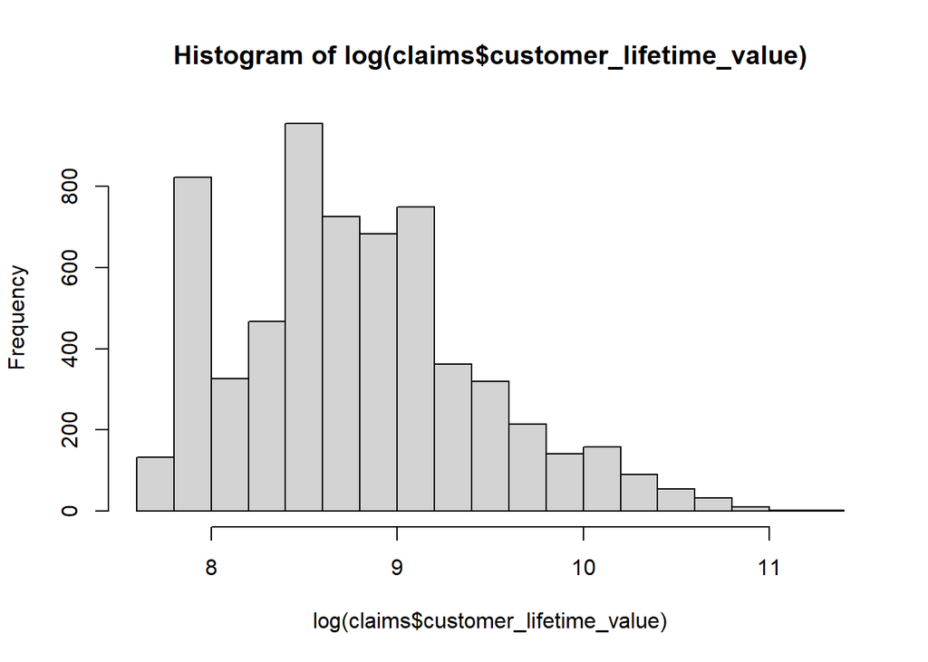

```r
hist(log(claims$customer_lifetime_value))
```

## The technique that I selected is log transformation. As we can see from the histogram, the data is right skewed. For skewed distributions, we should find the relative error. In log transformation the errors are multiplicative and therefor reduce the relative error thereby improving the results. That is why I select log transformation to improve the results.

```r
log_claims <- claims%>%mutate(customer_lifetime_value=log(customer_lifetime_value))
```

```r
set.seed(271)
claims_split_log<-initial_split(log_claims, prop=.8)
claims_training_log<-claims_split_log%>% training()
claims_test_log<-claims_split_log%>% testing()
```

## Metrics of testing data

```r
multi_metric<-metric_set(yardstick::rmse, mape, mae, rsq)

multi_metric(testing_result, truth=customer_lifetime_value, estimate=.pred)
```

```
## # A tibble: 4 x 3
##   .metric .estimator .estimate
##   <chr>   <chr>          <dbl>
## 1 rmse    standard    6443.
## 2 mape    standard      58.4
## 3 mae     standard    3981.
## 4 rsq     standard       0.160
```

```r
model_fit_log<-claims_workflow%>%fit(data=claims_training_log)

test_results_log=predict(model_fit_log, claims_test_log)%>%bind_cols(claims_test_log%>%select(customer_lifetime_value))

multi_metric(test_results_log, truth = exp(customer_lifetime_value), estimate = exp(.pred))
```

```
## # A tibble: 4 x 3
##   .metric .estimator .estimate
##   <chr>   <chr>          <dbl>
## 1 rmse    standard    6411.
## 2 mape    standard      45.2
## 3 mae     standard    3528.
## 4 rsq     standard       0.161
```

## B. Show the performance improvement by comparing the model evaluations of the new model with the old one. Which performance metric did you use while trying to improve the model, briefly explain why you chose your metric ?

```r
multi_metric(testing_result, truth=customer_lifetime_value, estimate=.pred)
```

```
## # A tibble: 4 x 3
##   .metric .estimator .estimate
##   <chr>   <chr>          <dbl>
## 1 rmse    standard    6443.
## 2 mape    standard      58.4
## 3 mae     standard    3981.
## 4 rsq     standard       0.160
```

```r
multi_metric(test_results_log, truth = exp(customer_lifetime_value), estimate = exp(.pred))
```

```
## # A tibble: 4 x 3
##   .metric .estimator .estimate
##   <chr>   <chr>          <dbl>
## 1 rmse    standard    6411.
## 2 mape    standard      45.2
## 3 mae     standard    3528.
## 4 rsq     standard       0.161
```

## From the performance metrics above we can see the performance improvement in the new model compared to the old model. The performance metric that I used while trying to improve my model is Mean Absolute Percentage Error (MAPE). I choose this as my metric because we are interested in the relative error and for that we use proportional error metric and MAPE is one of them. As we can see the old model has a MAPE value of 58.38 and the new model has a MAPE value of 45.22 which is less than the old model. Since MAPE is a metric of error, the lesser value signifies improvement in the model.

## PART 2

```r
h_disease=read_csv(url('https://ygenc.github.io/lectures/data/heart_disease.csv'))
h_disease
```

```
## # A tibble: 303 x 15
##    patient_id heart_disease   age gender chest_pain resting_blood_p~ cholesterol
##         <dbl> <chr>         <dbl> <chr>  <chr>                 <dbl>       <dbl>
##  1       1001 no               63 male   typical                 145         233
##  2       1002 yes              67 male   asymptoma~              160         286
##  3       1003 yes              67 male   asymptoma~              120         229
##  4       1004 no               37 male   non_angin~              130         250
##  5       1005 no               41 female atypical                130         204
##  6       1006 no               56 male   atypical                120         236
##  7       1007 yes              62 female asymptoma~              140         268
##  8       1008 no               57 female asymptoma~              120         354
##  9       1009 yes              63 male   asymptoma~              130         254
## 10       1010 yes              53 male   asymptoma~              140         203
## # ... with 293 more rows, and 8 more variables: fasting_blood_sugar <chr>,
## #   resting_electrocardiograph <chr>, max_heart_rate <dbl>,
## #   exercise_angina <chr>, old_peak <dbl>, slope <chr>,
## #   vessel_fluoroscopy <dbl>, thalassemia <chr>
```

## 3. A Create a prediction model for detecting heart disease outcome variable.

```r
patient_data <- h_disease %>%
                 mutate(heart_disease = factor(heart_disease,
                                              levels = c('yes', 'no')))

levels(patient_data$heart_disease)
```

```
## [1] "yes" "no"
```

```r
set.seed(323)

p_split <- initial_split(patient_data,
                                strata = heart_disease)

p_training <- p_split %>% training()

p_test <- p_split %>% testing()
```

```r
p_recipe <- recipe(heart_disease ~ ., data = p_training)
```

```r
p_recipe %>%
  prep() %>%
  bake(new_data = p_training)
```

```
## # A tibble: 228 x 15
##    patient_id   age gender chest_pain resting_blood_p~ cholesterol
##         <dbl> <dbl> <fct>  <fct>                 <dbl>       <dbl>
##  1       1003    67 male   asymptoma~              120         229
##  2       1004    37 male   non_angin~              130         250
##  3       1005    41 female atypical                130         204
##  4       1007    62 female asymptoma~              140         268
##  5       1008    57 female asymptoma~              120         354
##  6       1009    63 male   asymptoma~              130         254
##  7       1011    57 male   asymptoma~              140         192
##  8       1012    56 female atypical                140         294
##  9       1013    56 male   non_angin~              130         256
## 10       1016    57 male   non_angin~              150         168
## # ... with 218 more rows, and 9 more variables: fasting_blood_sugar <fct>,
## #   resting_electrocardiograph <fct>, max_heart_rate <dbl>,
## #   exercise_angina <fct>, old_peak <dbl>, slope <fct>,
## #   vessel_fluoroscopy <dbl>, thalassemia <fct>, heart_disease <fct>
```

```r
logistic_model <- logistic_reg() %>%
                  set_engine('glm', control=glm.control(maxit=50))%>%
                  set_mode('classification')

employee_wf <- workflow() %>%
               add_model(logistic_model) %>%
               add_recipe(p_recipe)



model_fit<-employee_wf%>% fit(  data = p_training)


test_result2=predict(model_fit, new_data = p_test)%>%bind_cols(p_test%>%select(heart_disease))

test_result2
```

```
## # A tibble: 75 x 2
##    .pred_class heart_disease
##    <fct>       <fct>
##  1 no          no
##  2 yes         yes
##  3 no          no
##  4 yes         yes
##  5 no          no
##  6 no          no
##  7 no          no
##  8 yes         no
##  9 no          no
## 10 no          no
## # ... with 65 more rows
```

## B. Show accuracy of the model with a confusion matrix.

```r
conf_mat(test_result2, truth = heart_disease, estimate = .pred_class)
```

```
##           Truth
## Prediction yes no
##        yes  25  5
##        no    9 36
```

## C. See if you can make any improvements on your model.

```r
p_recipe_new <- recipe(heart_disease ~ ., data = p_training, family='binomial') %>%
                   step_range(all_numeric(), -all_outcomes()) %>%
                  step_rm(patient_id)%>%
                   step_dummy(all_nominal(), -all_outcomes())%>%
                  step_nzv(all_predictors())
```

```r
p_recipe_new %>%
  prep() %>%
  bake(new_data = p_training)
```

```
## # A tibble: 228 x 18
##      age resting_blood_p~ cholesterol max_heart_rate old_peak vessel_fluorosc~
##    <dbl>            <dbl>       <dbl>          <dbl>    <dbl>            <dbl>
##  1 0.792            0.245      0.235           0.443   0.419             0.667
##  2 0.167            0.340      0.283           0.885   0.565             0
##  3 0.25             0.340      0.178           0.771   0.226             0
##  4 0.688            0.434      0.324           0.679   0.581             0.667
##  5 0.583            0.245      0.521           0.702   0.0968            0
##  6 0.708            0.340      0.292           0.580   0.226             0.333
##  7 0.583            0.434      0.151           0.588   0.0645            0
##  8 0.562            0.434      0.384           0.626   0.210             0
##  9 0.562            0.340      0.297           0.542   0.0968            0.333
## 10 0.583            0.528      0.0959          0.786   0.258             0
## # ... with 218 more rows, and 12 more variables: heart_disease <fct>,
## #   gender_male <dbl>, chest_pain_atypical <dbl>, chest_pain_non_anginal <dbl>,
## #   chest_pain_typical <dbl>, fasting_blood_sugar_less_120_mg <dbl>,
## #   resting_electrocardiograph_ventricular_hypertrophy <dbl>,
## #   exercise_angina_yes <dbl>, slope_flat <dbl>, slope_upsloping <dbl>,
## #   thalassemia_normal <dbl>, thalassemia_reversible_defect <dbl>
```

```r
logistic_model <- logistic_reg() %>%
                  set_engine('glm', control=glm.control(maxit=50))%>%
                  set_mode('classification')

employee_wf <- workflow() %>%
               add_model(logistic_model) %>%
               add_recipe(p_recipe_new)



model_fit<-employee_wf%>% fit(  data = p_training)


test_result3=predict(model_fit, new_data = p_test)%>%bind_cols(p_test%>%select(heart_disease))

test_result3
```

```
## # A tibble: 75 x 2
##    .pred_class heart_disease
##    <fct>       <fct>
##  1 no          no
##  2 yes         yes
##  3 no          no
##  4 yes         yes
##  5 no          no
##  6 no          no
##  7 no          no
##  8 yes         no
##  9 no          no
## 10 no          no
## # ... with 65 more rows
```

```r
conf_mat(test_result3, truth = heart_disease, estimate = .pred_class)
```

```
##           Truth
## Prediction yes no
##        yes  26  5
##        no    8 36
```

## I removed “patient_id” in recipe and also used ‘step_nzv(all_predictors())’ which removes highly sparce and unbalanced variables to improve the model.